# Ponto 8 - Amostragem Sistemática

Gabriel Agostini Orso

Data de Publicação

28 de março de 2026

# 1 Preâmbulo

**AvisoAviso**

Antes de prosseguir, o leitor deve estar ciente de que o material aqui utilizado foi elaborado com o único objetivo de estudo pessoal, portanto muitas passagens são fruto de conhecimento e interpretação pessoal. No entanto, ainda assim esse texto faz uso extensivo da literatura científica apresentada ao fim do trabalho, mas **por ser material pessoal de estudo** muitas passagens não fazem a devida citação das obras consultadas, tal qual se esperaria de trabalhos científicos.

Além isso, não foram utilizadas ferramentas de inteligência artificial como *chatGPT*, *Gemini*, *Manus* ou outras para a construção do texto. Toda a sequência lógica, exemplos, entendimentos e escrita são de responsabilidade do autor.

Com essas condições em mente, espero que esse material seja oportuno. Boa leitura.

# 2 Introdução

A principal obra no tema é, sem dúvida, *Sampling Techniques*, de William G. Cochran (Cochran, 1977), em que o autor resume de maneira apropriada os principais estimadores desse ramo.

A amostragem é um dos pilares da estatística aplicada e encontra ampla utilização na área de inventários florestais. Dentre os diferentes delineamentos amostrais existentes, a amostragem sistemática ocupa posição de destaque por sua simplicidade operacional, pelo recobrimento uniforme da área de estudo e pela facilidade de aplicação em campo. Tais características a tornam o método preferencial em muitos inventários florestais realizados por empresas e instituições públicas.

Apesar de sua ampla adoção, a amostragem sistemática apresenta desafios consideráveis no campo teórico. Ao contrário da amostragem casual simples (ACS), a sistemática implica dependência entre unidades amostrais e, portanto, não satisfaz os pressupostos clássicos de independência e equiprobabilidade. Essa particularidade dificulta a obtenção de estimadores não viesados da variância, além de suscitar dúvidas quanto à validade estatística de inferências baseadas nesse tipo de delineamento.

O presente texto propõe apresentar a amostragem sistemática sob múltiplas perspectivas: desde seus fundamentos teóricos e operacionais até sua aproximação com modelos de amostragem por conglomerados e estratificada. Além disso, discute-se a possibilidade de tratamento da sistemática como se fosse uma ACS sob certas condições, bem como a aplicação de técnicas corretivas e alternativas para a estimação da variância da média amostral. Por fim, são abordadas novas tecnologias que vêm modernizando a prática da amostragem em inventários, ampliando o potencial analítico dos dados coletados e a eficiência na execução de campo.

# 3 Fundamentação teórica

Para se compreender o processo de amostragem sistemática, é preciso antes compreender a amostragem como teoria geral. Todo o desenvolvimento de estimadores e suas propriedades decorre do sólido entendimento dos princípios estatísticos que garantem a confiabilidade dos inventários realizados. O primeiro passo desse caminho é compreender o objeto de estudo de inventários e amostragens de maneira geral. E isso se inicia com uma rápida recapitulação do processo amostral que gerou os demais, a amostragem casual simples.

Em um inventário florestal, ou de maneira geral em uma amostragem, deseja-se estimar uma quantidade como uma média $\bar{Y}$ ou um total $Y$ de certa população de tamanho $N$. Note que, à medida que $N$ cresce, torna-se mais impraticável mensurar ou observar todos os indivíduos dessa população, e disso surge a proposta de mensurar apenas um subconjunto dessa população, chamado de amostra, que possui tamanho $n$. Essa amostra é tomada de forma aleatória na população, isto é, cada elemento que compõe a amostra possui a mesma probabilidade de ser selecionado.

É lógico raciocinar que, embora desejável, torna-se impossível obter o valor da população inteira, como a média populacional $\bar{Y}$. Em vez disso, a informação está limitada à amostra de tamanho $n$, que será utilizada para extrair informações da população. Desse raciocínio surge a ideia de estimador, isto é, uma certa quantidade obtida da amostra, mas que procura representar o valor populacional.

Veja que, em uma amostra, a quantidade populacional ou parâmetro é sempre desconhecida, mas existem estimadores que são julgados adequados para serem usados em determinadas situações. Seja a média amostral $\bar{y}$, por exemplo: esse pode ser um estimador da média populacional.

$$\bar{y} = \frac{1}{n}\sum_{i=1}^{n} y_i$$

Onde $\bar{y}$ é a média amostral, $n$ é o tamanho da amostra e $y_i$ são os elementos que constituem a amostra, tais que $i \in 1,2,\ldots,n$.

Note que tal amostra de tamanho $n$ é ainda apenas uma amostra dentre diversas possíveis na população. Na verdade, existem $_{N}C_n$ possíveis amostras diferentes de tamanho $n$.

$$_{N}C_n = \binom{N}{n} = \frac{N!}{n!(N-n)!}$$

Onde $_{N}C_n$ é o número de amostras possíveis, $N$ é o tamanho da população e $n$ é o tamanho da amostra.

Ou seja, supondo que as possíveis amostras são independentes, a probabilidade de selecionar uma amostra é de $\frac{1}{_NC_n}$. Essa é a probabilidade de ocorrência de uma determinada amostra e, consequentemente, a probabilidade de ocorrer uma dada média amostral $\bar{y}$. Em outras palavras, $\bar{y}$ é uma variável aleatória, que possui sua distribuição de probabilidade associada.

A maneira de se determinar se $\bar{y}$ ou qualquer outro estimador é adequado leva em conta dois princípios: o do viés e o da consistência. Um estimador é considerado não viesado se sua esperança é igual ao valor paramétrico, isto é, se

$$E[\bar{y}] = \bar{Y}$$

Onde $E[\cdot]$ é o operador de esperança de uma variável aleatória.

Pode ser provado que, de fato, $\bar{y}$ é não viesado para $\bar{Y}$. Já a consistência é atestada verificando se o estimador tende ao parâmetro quando a amostra aumenta, isto é, se o estimador irá resultar no parâmetro quando $n \to N$.

$$\bar{y} = \frac{1}{n}\sum_{i=1}^{n} y_i \xrightarrow[n \to N]{} \frac{1}{N}\sum_{i=1}^{N} y_i = \bar{Y}$$

De forma análoga, todos os demais estimadores da amostragem casual simples possuem essa propriedade de consistência e ausência de viés. Essa condição é muito importante, pois diversos dos demais processos de amostragem são derivados da ACS.

Visto que a média amostral é incerta, existe uma variância associada à estimativa da média amostral. A variância da média amostral é dada por

$$V[\bar{y}] = \frac{S^2}{n}\frac{N-n}{N} = \frac{S^2}{n}(1-f)
\tag{2}$$

Onde $V[\cdot]$ é o operador de variância, $S^2$ é a variância da população e $f = \frac{n}{N}$ é a fração amostral.

Veja que $V[\bar{y}]$, a variância da média, faz uso da variância das observações $S^2$. A fração amostral $f$ representa a proporção da população que foi de fato amostrada. No Brasil, o trabalho de Péllico Netto e Brena (1997) criou grande consenso de que, se $f < 0{,}02$, então a população será *considerada infinita* e o termo $(1-f)$ pode ser omitido do cálculo, o que simplifica algumas fórmulas. Cochran (1977), no entanto, afirma que, para $f < 0{,}05$, esse efeito já é desprezível. Caso contrário, a população é dita finita, e o termo deve ser mantido.

Entretanto, $S^2$ é desconhecido, pois apenas uma amostra foi tomada, e por isso é substituído por seu estimador não viesado e consistente $s^2$:

$$S^2 = \frac{1}{N-1}\sum_{i=1}^{N}(y_i-\bar{Y})^2
\qquad
s^2 = \frac{1}{n-1}\sum_{i=1}^{n}(y_i-\bar{y})^2$$

Onde $S^2$ é a variância da população e $s^2$ é o estimador da variância da população.

Dessa forma, ao substituir $S^2$ por $s^2$, a variância da média amostral passa a ser estimada. Portanto,

$$\hat{V}[\bar{y}] = \frac{s^2}{n}(1-f)$$

Onde $\hat{V}[\bar{y}]$ é o estimador da variância da média amostral.

A consideração de população finita ou infinita é muito mais profunda do que apenas facilitar cálculos, e representa a convergência de duas linhas estatísticas diferentes do estudo da amostragem. De um lado está o ramo da Teoria da Pesquisa por Amostragem (TPA), que é a principal linha seguida em amostragem e inventários florestais de maneira geral e foi compilada principalmente por William G. Cochran em seu livro *Sampling Techniques* (Cochran, 1977).

Diferentemente de outras áreas da estatística, a TPA não assume nenhuma distribuição de probabilidade para as variáveis e assume que a população de interesse seja sempre finita. Como não há distribuição de probabilidade associada, os estimadores são encontrados basicamente a partir do desenho amostral utilizado. E uma grande vantagem disso é que os estimadores são exatos, isto é, são adequados tanto para amostras pequenas quanto grandes.

Por outro lado, existe a Teoria da Amostragem Clássica (TAC), que presume a existência de uma população infinita ($N \to \infty$), assume uma distribuição de probabilidade para a variável e possui estimadores com propriedades assintóticas, isto é, possuem convergência quando o tamanho da amostra cresce.

O principal resultado utilizado por essa linha é, sem dúvida, o Teorema Central do Limite (TCL), que atesta que a média de uma sequência de variáveis independentes e identicamente distribuídas de variância finita tende a uma distribuição normal padrão quando $n \to \infty$, isto é, se $E[X_i] = \mu$ e $V[X_i] = \sigma^2$ para todo $i \in 1,2,\ldots,n$, então

$$\frac{\bar{X}-\mu}{\sigma/\sqrt{n}} \xrightarrow{D} N(0,1)$$

Onde $\xrightarrow{D}$ representa convergência em distribuição.

E, por consequência, assume-se que

$$\bar{X} \sim N\left(\mu,\frac{\sigma^2}{n}\right)$$

Perceba a proximidade do valor da variância com a variância da média utilizada em $\hat{V}[\bar{y}]$. Portanto, assumir que a população é infinita é, na teoria, fazer uso da abordagem TAC. Na prática, ambas as linhas de estudo irão convergir conforme $N$ cresce e o resultado tenderá a ser o mesmo. Ainda assim, nas fórmulas a seguir é dada ênfase aos estimadores para população finita, pois são mais congruentes com a abordagem da pesquisa por amostragem e fornecem estimadores não viesados para qualquer tamanho de amostra.

# 4 Amostragem sistemática

De maneira contrária ao processo de amostragem casual (ACS), a amostragem sistemática (AS) é caracterizada pela obtenção de uma amostra $n$ de maneira sistematizada, isto é, de uma forma não aleatória (Péllico Netto e Brena, 1997). Em um primeiro momento, tal abordagem parece ser contrária à ideia geral de amostragens, mas é um dos processos mais utilizados em inventários florestais.

## 4.1 Vantagens

A principal razão da grande adoção da amostragem sistemática em inventários florestais é a facilidade de operacionalização e a diminuição dos custos de inventário. Ao contrário da ACS, a AS proporciona um intervalo regular de distâncias entre parcelas, e isso permite melhor planejamento da execução do inventário, pois evita a ocorrência de parcelas muito distantes entre si. O arranjo sistemático da amostra também permite a obtenção de parcelas sem necessariamente se conhecer a população $N$, pois, com um intervalo de amostragem fixado, há a garantia de que, para cada aumento da população, haverá também aumento da amostra.

Além das vantagens operacionais, a amostragem sistemática pode trazer melhorias nas estimativas dos parâmetros, a depender de algumas condições que serão abordadas em seguida. Uma clara vantagem da amostragem sistemática é o recobrimento uniforme da população, e isso proporciona uma boa estimativa da média e do total populacional.

Respeitadas as devidas condições, os estimadores são mais precisos do que se a amostra fosse obtida de forma aleatória. Queiroz (2012) atribui essa maior precisão ao fato de a amostragem sistemática evitar a ocorrência de parcelas de inventário muito próximas umas das outras, diminuindo a correlação entre diferentes parcelas. Já outros autores, como Cochran (1977), atribuem essa maior precisão à abordagem de cálculo da amostragem sistemática, que pode ser vista como um caso particular de Amostragem Casual Estratificada (ACE), e esta é obrigatoriamente tão ou mais precisa que uma ACS.

## 4.2 Ideia de sistematização

A sistematização da amostra pode ser feita com qualquer critério que resulte em uma adoção regular de unidades amostrais. Em inventários florestais, pode ser feita em qualquer método de amostragem, seja ele de área fixa, faixas ou até mesmo pontos amostrais para áreas variáveis. Tomando como exemplo a criação de um *grid* que recobre a população, é possível selecionar diversas possíveis amostras a intervalos regulares na floresta (Figura 1).

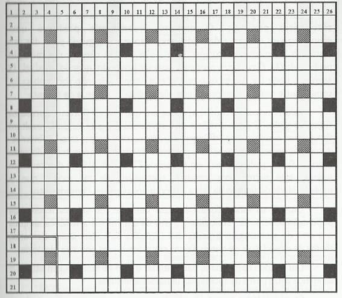

Figura 1: Exemplo de sistematização da amostra com duas possíveis amostras sistemáticas. Adaptado de Péllico Netto & Brena (1997)

### 4.2.1 Intervalo de amostragem (k)

O primeiro passo é a definição de um intervalo $k$ que definirá o espaçamento entre unidades amostrais para ambas as direções. Como cada unidade amostral é separada linearmente por $k$ unidades, então existem $k\cdot k$ unidades possíveis.

A partir daí existem duas formas de sistematização, que representam maneiras de selecionar a primeira unidade amostral.

A primeira forma consiste em iniciar a sistematização a partir de um ponto aleatório na área. Seja, por exemplo, $k=3$ em um *grid* com 40 linhas e 50 colunas. O método consiste em sortear uma linha e uma coluna qualquer no *grid*, por exemplo linha 20 e coluna 15. A seguir, divide-se a linha e a coluna por $k\cdot k = 9$ e toma-se o numerador do resto, isto é,

$$\frac{20}{9} = 1 + \frac{11}{9}
\qquad \text{e} \qquad
\frac{15}{9} = 1 + \frac{6}{9}$$

Portanto, a primeira parcela selecionada será a parcela localizada na linha 11 e coluna 6 do *grid*. A partir dessa primeira parcela, as demais são selecionadas sistematicamente a cada $k$ unidades para ambas as direções.

O segundo método consiste em organizar o *grid* em grandes blocos contíguos de $k\cdot k$ unidades. Seleciona-se um bloco de algum vértice do *grid*, por exemplo o canto inferior esquerdo, e sorteia-se um número entre 1 e $k\cdot k$, por exemplo 5. Então a primeira parcela selecionada será a parcela de número 5 desse primeiro bloco. A seguir, as novas parcelas serão selecionadas sistematicamente a cada $k$ unidades em ambas as direções.

Aqui dois pontos merecem atenção. O primeiro ponto é que, se $k$ não for múltiplo das linhas e colunas, ou de forma mais genérica se $k$ não for múltiplo de $N$, então a escolha da primeira parcela vai resultar em diferentes tamanhos de amostra. O segundo ponto é que apenas a primeira parcela é aleatorizada. Todas as demais são automaticamente escolhidas a partir da seleção da primeira.

## 4.3 Problema de populações com padrão

### 4.3.1 Tendência periódica

Veja ainda que, se por alguma razão, existir um comportamento periódico na população, e que coincida com o mesmo intervalo $k$ utilizado, então a amostra poderá resultar em estimativas drasticamente viesadas, como exemplificado na Figura 2. Caso as unidades amostrais recaiam sempre no mesmo ponto desse comportamento periódico, *e.g.*, no topo da variação, então todas as estimativas serão superestimadas. De maneira complementar, se as unidades amostrais recaírem sobre a média ou recobrirem de forma adequada esse comportamento periódico, então as estimativas serão confiáveis.

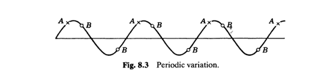

Figura 2: Relação entre amostragem sistemática e um comportamento periódico na população. Adaptado de Cochran (1977)

### 4.3.2 Tendência linear

O comportamento exemplificado na Figura 2 é apenas um de diversos comportamentos possíveis de ocorrer em uma população. Em populações biológicas, no entanto, não é esperado que tal comportamento seja observado (Péllico Netto e Brena, 1997). Outro padrão possível é a ocorrência de uma tendência na população (Figura 3). Quando presentes, tais condições podem impactar a estimativa dos valores populacionais de interesse.

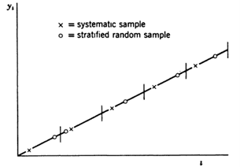

Figura 3: Exemplo de tendência linear na população e sua representação na amostragem sistemática. Adaptado de Cochran (1977)

O fato de apenas a primeira parcela ser selecionada aleatoriamente é de extrema relevância no tema, pois é condição diametralmente oposta ao estipulado nos demais processos de amostragem, isto é, as parcelas não são independentes entre si. Essa diferença faz da amostragem sistemática um caso de difícil resolução na estatística, especialmente os estimadores de variância. Em verdade, não há estimador não viesado e consistente para a variância de uma amostra obtida de forma sistemática (Cochran, 1977); no entanto, a literatura traz diversas alternativas viáveis e consideravelmente precisas sob certas condições. Inicialmente serão traçadas abordagens via amostragem por conglomerado (AC) e amostragem casual estratificada (ACE), e, por fim, a abordagem via amostragem aleatória simples, mais comumente utilizada na área florestal (Queiroz, 2012).

## 4.4 Aproximação com amostragem por conglomerado

Supondo que $N = n\cdot k$ e com as parcelas dispostas de acordo com a Tabela 1, fica evidente que a população pode ser dividida em $k$ grandes grupos de unidades amostrais (ou conglomerados), cada uma contendo $n$ unidades. A operação de escolher aleatoriamente uma amostra sistemática pode ser vista, então, como a operação de escolher **um** desses grandes grupos de forma aleatória. Portanto, a amostragem sistemática é uma amostragem aleatória simples de uma unidade de conglomerado de uma população de $k$ conglomerados.

Tabela 1: Arranjo das $k$ possíveis amostras sistemáticas. (Adaptado de Cochran (1977))

|  | 1 | 2 | $\cdots$ | $i$ | $\cdots$ | $k$ |
| --- | --- | --- | --- | --- | --- | --- |
|  | $y_1$ | $y_2$ | $\cdots$ | $y_i$ | $\cdots$ | $y_k$ |
|  | $y_{k+1}$ | $y_{k+2}$ | $\cdots$ | $y_{k+i}$ | $\cdots$ | $y_{2k}$ |
|  | $\vdots$ | $\vdots$ | $\ddots$ | $\vdots$ | $\ddots$ | $\vdots$ |
|  | $y_{(n-1)k+1}$ | $y_{(n-1)k+2}$ | $\cdots$ | $y_{(n-1)k+i}$ | $\cdots$ | $y_{nk}$ |
| Means | $\bar{y}_1$ | $\bar{y}_2$ | $\cdots$ | $\bar{y}_i$ | $\cdots$ | $\bar{y}_k$ |

Nessa lógica, os mesmos estimadores da amostragem por conglomerados podem ser utilizados, como a média amostral:

$$\bar{y}_{si} = \frac{1}{kn}\sum_{i=1}^{k}\sum_{j=1}^{n} y_{ij}$$

Onde $\bar{y}_{si}$ é a média da amostra sistemática, $k$ é o número de conglomerados, $n$ é o número de unidades amostrais dentro do *cluster* e $y_{ij}$ é o valor da variável da $j$-ésima unidade amostral do $i$-ésimo conglomerado.

Como $k=1$, pois a amostra é composta de apenas um conglomerado, a média amostral se resume a

$$\bar{y}_{si} = \frac{1}{n}\sum_{j=1}^{n} y_j$$

Naturalmente, a variância da média amostral é calculada como as diferenças quadráticas de todas as possíveis amostras sistemáticas com a média populacional. Como cada amostra é vista como um conglomerado, então equivale às diferenças quadráticas entre médias dos conglomerados com a média populacional:

$$V[\bar{y}_{si}] = \frac{1}{k}\sum_{i=1}^{k}(\bar{y}_i - \bar{Y})^2
\tag{1}$$

Onde $V[\cdot]$ é o operador de variância, $\bar{y}_i$ é a média da $i$-ésima amostra sistemática possível e $\bar{Y}$ é a média populacional.

Já a variância das observações $S^2$ é calculada como

$$S^2 = \frac{1}{N-1}\sum_{i=1}^{k}\sum_{j=1}^{n}(y_{ij}-\bar{Y})^2
\tag{2}$$

Onde $S^2$ é a variância das observações.

Partindo do Resultado 2, a variância da média $V[\bar{y}_{si}]$ pode ser então escrita como

$$\begin{aligned}
(N-1)S^2 &= \sum_{i=1}^{k}\sum_{j=1}^{n}(y_{ij}-\bar{Y})^2 = \sum_{i=1}^{k}\sum_{j=1}^{n}(y_{ij}-\bar{y}_i+\bar{y}_i-\bar{Y})^2 = \\
&= \sum_{i=1}^{k}\sum_{j=1}^{n}\left[(y_{ij}-\bar{y}_i)+(\bar{y}_i-\bar{Y})\right]^2 \\
&= \displaystyle\sum_{i=1}^{k} \displaystyle\sum_{j=1}^{n} \left((y_{ij} - \bar{y}_i)^2 + 2(y_{ij} - \bar{y}_i)(\bar{y}_i - \bar{Y}) + (\bar{y}_i - \bar{Y})^2\right) = \\
&= \sum_{i=1}^{k}\sum_{j=1}^{n}(y_{ij}-\bar{y}_i)^2 + 2\sum_{i=1}^{k}(\bar{y}_i-\bar{Y})\sum_{j=1}^{n}(y_{ij}-\bar{y}_i) + \sum_{i=1}^{k} n(\bar{y}_i-\bar{Y})^2
\end{aligned}$$

Veja que $\sum_{j=1}^{n}(y_{ij}-\bar{y}_i)=0$. Assim,

$$\begin{aligned}
(N-1)S^2 &= \frac{k(n-1)}{k(n-1)}\sum_{i=1}^{k}\sum_{j=1}^{n}(y_{ij}-\bar{y}_i)^2 + \frac{k}{k}n\sum_{i=1}^{k}(\bar{y}_i-\bar{Y})^2 \\
&= k(n-1)S_{wsi}^{2} + knV[\bar{y}_{si}] \\
&= k(n-1)S^2_{wsi} + knV[\bar{y}_{si}]
\end{aligned}$$

Portanto,

$$\begin{aligned}
V[\bar{y}_{si}] &= {(N-1)S^2 \over kn} - {k(n-1)S^2_{wsi} \over kn} \\
&= \frac{N-1}{N}S^2 - \frac{k(n-1)}{N}S_{wsi}^{2}
\end{aligned}
\tag{3}$$

Onde $V[\bar{y}_{si}]$ é a variância da média amostral obtida de forma sistemática, $S^2$ é a variância da população e $S_{wsi}^{2}$ é a variância dentro dos conglomerados.

Veja que a variância dentro dos conglomerados é calculada como

$$S_{wsi}^{2} = \frac{1}{k(n-1)}\sum_{i=1}^{k}\sum_{j=1}^{n}(y_{ij}-\bar{y}_i)^2
\tag{4}$$

E $S_{wsi}^{2}$ pode ser interpretada como a média da variância dentro de cada conglomerado. O denominador reflete isso, pois cada conglomerado (ou possível parcela sistemática) contribui com $n-1$ graus de liberdade.

Um corolário importante do Resultado 3 é o de que a média de uma amostra sistemática é mais precisa que a média de uma amostra aleatória se, e somente se,

$$S_{wsi}^{2} > S^2$$

Isto é, se a variância dentro do conglomerado é maior que a variância da população. Isso se verifica, pois, tomando a variância da média de uma amostra aleatória simples,

$$V[\bar{y}_{aas}] = \frac{S^2}{n}\frac{N-n}{N}$$

Então,

$$\begin{aligned}
V[\bar{y}_{si}] &< V[\bar{y}_{aas}] \\
\frac{N-1}{N}S^2 - \frac{k(n-1)}{N}S_{wsi}^{2} &< \frac{S^2}{n}\frac{N-n}{N} \\
\frac{N-1}{N}S^2 - \frac{S^2}{n}\frac{N-n}{N} &< \frac{k(n-1)}{N}S_{wsi}^{2} \\
S^2\left(\frac{Nn-n-N+n}{n}\right) &< k(n-1)S_{wsi}^{2} \\
S^2\frac{N(n-1)}{n} &< k(n-1)S_{wsi}^{2}
\end{aligned}$$

Como $N = nk$, então

$$\begin{aligned}
S^2\frac{nk(n-1)}{n} &< k(n-1)S_{wsi}^{2} \\
S^2 k(n-1) &< k(n-1)S_{wsi}^{2} \\
S^2 &< S_{wsi}^{2}
\end{aligned}$$

Outra forma para a variância da amostragem sistemática é obtida por meio da correlação entre unidades amostrais (Cochran, 1977):

$$V[\bar{y}_{si}] = \frac{S^2}{n}\frac{N-1}{N}\left[1+(n-1)p_w\right]
\tag{5}$$

Onde $p_w$ é o coeficiente de correlação entre pares de unidades que estão na mesma amostra sistemática. É definida como

$$p_w = \frac{E[(y_{ij}-\bar{Y})(y_{iu}-\bar{Y})]}{E[(y_{ij}-\bar{Y})^2]}$$

Onde $E[\cdot]$ é o operador de esperança.

Veja que o numerador é uma média sobre todos os $kn(n-1)/2$ distintos pares, e o denominador é a média sobre os $N$ valores de $y_{ij}$. Como o denominador pode ser reescrito como $(N-1)S^2/N$, então

$$\begin{aligned}
p_w &= {\frac{1}{\frac{kn(n-1)}{2}} \over \frac{(N-1)S^2}{N}}\sum_{i=1}^{k}\sum_{j<u}(y_{ij}-\bar{Y})(y_{iu}-\bar{Y}) \\
&= \frac{2N}{kn(n-1)(N-1)S^2}\sum_{i=1}^{k}\sum_{j<u}(y_{ij}-\bar{Y})(y_{iu}-\bar{Y}) \\
&= \frac{2}{(n-1)(N-1)S^2}\sum_{i=1}^{k}\sum_{j<u}(y_{ij}-\bar{Y})(y_{iu}-\bar{Y})
\end{aligned}
\tag{6}$$

A prova do Resultado 5 segue.

$$\begin{aligned}
V[\bar{y}_{si}] &= \frac{1}{k}\sum_{i=1}^{k}(\bar{y}_i-\bar{Y})^2 \\
kV[\bar{y}_{si}] &= \sum_{i=1}^{k}(\bar{y}_i-\bar{Y})^2 = \sum_{i=1}^{k}\left(\frac{y_{i1}+y_{i2}+\cdots+y_{in}}{n} - \bar{Y}\right)^2 \\
&= \sum_{i=1}^{k}\left[\frac{1}{n}(y_{i1}+y_{i2}+\cdots+y_{in}) - \frac{n\bar{Y}}{n}\right]^2 \\
&= \sum_{i=1}^{k}\left[\frac{1}{n}(y_{i1}+y_{i2}+\cdots+y_{in}-n\bar{Y})\right]^2 \\
&= \displaystyle\sum_{i=1}^{k} \left( {1 \over n^2} (y_{i1} + y_{i2} + \cdots + y_{in} - n \bar{Y})^2\right) \\
&= {1 \over n^2} \displaystyle\sum_{i=1}^{k} (y_{i1} + y_{i2} + \cdots + y_{in} - \bar{Y} - \bar{Y} - \cdots - \bar{Y})^2 \\
&= {1 \over n^2} \displaystyle\sum_{i=1}^{k} \left( (y_{i1} - \bar{Y}) +(y_{i2} - \bar{Y}) + \cdots + (y_{in} - \bar{Y})\right)^2 = kV[\bar{y}_{st}]
\end{aligned}$$

Portanto,

$$\begin{aligned}
n^2kV[\bar{y}_{si}] &= \sum_{i=1}^{k}\left[(y_{i1}-\bar{Y}) + (y_{i2}-\bar{Y}) + \cdots + (y_{in}-\bar{Y})\right]^2 \\
&= \sum_{i=1}^{k}\sum_{j=1}^{n}(y_{ij}-\bar{Y})^2 + 2\sum_{i=1}^{k}\sum_{j<u}(y_{ij}-\bar{Y})(y_{iu}-\bar{Y})
\end{aligned}$$

Veja que, pelo Resultado 2, a primeira parte pode ser reescrita como $(N-1)S^2$, e a segunda parte é componente do Resultado 6. Portanto,

$$\begin{aligned}
n^2kV[\bar{y}_{si}] &= nN V[\bar{y}_{si}] = (N-1)S^2 + (n-1)(N-1)S^2 p_w \\
nN V[\bar{y}_{si}] &= (N-1)S^2\left[1+(n-1)p_w\right] \\
V[\bar{y}_{si}] &= \frac{N-1}{N}\frac{S^2}{n}\left[1+(n-1)p_w\right]
\end{aligned}$$

O que completa a prova.

Apesar de uma solução teórica, nem o Resultado 3 nem o Resultado 5 possuem estimadores apropriados, pois, sob a perspectiva da amostragem por conglomerados, apenas uma unidade amostral foi obtida: $k=1$.

Na prática, uma alternativa seria separar a amostra sistemática em $k'$ conglomerados arbitrários e processá-la tal qual um inventário por conglomerados (Queiroz, 2012). Por exemplo, se uma amostra sistemática é composta por 50 parcelas, então divide-se a amostra em $k' = 10$ conglomerados com 5 subunidades cada, ou então $k' = 5$ conglomerados com 10 subunidades cada. Assim, conseguir-se-ia obter estimativa de variância da média e delimitar um erro de amostragem e intervalo de confiança.

### 4.4.1 Múltiplos inícios aleatórios

Nessa mesma lógica, Péllico Netto e Brena (1997) abordam a amostragem **sistemática com múltiplos inícios aleatórios**. O raciocínio é o mesmo do abordado por Queiroz (2012), porém, em vez de formar conglomerados *a posteriori*, esses são formados ainda no planejamento do inventário, ou seja, são planejadas $k$ amostras sistemáticas justapostas na área. Note que aqui $k$ representa o número de conglomerados, diferente da notação utilizada pelos autores.

O nome da técnica é derivado da necessidade de escolha de $k$ parcelas iniciais, uma para cada amostra sistemática. Como consequência, existirão $k$ inícios aleatórios. A estrutura dessa amostragem é tal qual a de amostragem por conglomerados e possui a vantagem de maximizar a variância dentro dos conglomerados, o que é uma grande vantagem para maior precisão.

A escolha do número de inícios aleatórios tem impacto significativo na precisão da amostragem. Apesar de fornecer um processo teoricamente condizente, muitos inícios aleatórios fazem a distribuição das unidades se aproximar de uma amostra aleatória, e uma amostra aleatória amostrada como por conglomerado é menos precisa. Por outro lado, a inferência do erro de amostragem, que faz uso de $k-1$ graus de liberdade como parâmetro, fornecerá valores muito altos para poucos inícios aleatórios.

A determinação do número de parcelas necessárias para satisfazer o erro de amostragem segue tal qual a metodologia para amostragem por conglomerado. Entretanto, Péllico Netto e Brena (1997) apresentam uma formulação para talvez especificar o tamanho ótimo dos conglomerados, isto é, o número de parcelas que compõe os conglomerados que minimiza a variância, a partir de uma função de decaimento exponencial:

$$\log(M) = \frac{1}{b}\left[\log(S^2)-\log(a)-\log(1+b)\right]$$

Onde $M$ é o tamanho do conglomerado, $a$ e $b$ são parâmetros da função de decaimento e $S^2$ é a variância das observações.

## 4.5 Aproximação com amostragem estratificada

De forma semelhante à abordagem por conglomerados, uma amostra sistemática pode ser vista sob a ótica de uma amostragem estratificada, em que cada estrato é composto por $k$ unidades amostrais, das quais apenas uma amostra é observada, tal qual o segundo método de escolha da parcela inicial na Figura 1. As formulações da variância da média se mantêm inalteradas.

## 4.6 Aparente relação com a ACS

Por fim, uma terceira forma de avaliar uma amostra sistemática é sob o ponto de vista da amostragem aleatória simples. Embora em um primeiro momento contraintuitivo, pode ser oportuna se o processo de sistematização das parcelas não tiver relação com a variável resposta, isto é, a ordem sistemática das parcelas ainda fornecer uma amostra aleatória de $y$ (Cochran, 1977). Tal condição é frequentemente atendida em florestas, portanto a abordagem da amostragem aleatória simples pode ser justificada.

Veja que, nesse caso, espera-se que uma amostragem sistemática seja essencialmente equivalente a uma amostragem aleatória simples e tenha mesma variância, $V_{si} = V_{aas}$. No entanto, para qualquer população finita, com dados valores de $n$ e $k$, isso não é exatamente verdade, pois $V_{si}$, que é baseado apenas em $k$ graus de liberdade, pode possuir comportamento errático quando $k$ é pequeno (Cochran, 1977). Afinal, quanto menor o valor de $k$, mais propenso é o sistema amostral de resultar em amostras de diferentes tamanhos, a depender da primeira parcela sorteada. Isso resulta em valores de $V_{si}$ que podem ser maiores ou menores que $V_{aas}$. Entretanto, em média, é esperado o mesmo resultado, mostrado a seguir.

Considere todas as $N!$ populações finitas que são formadas pelas $N!$ permutações de qualquer conjunto de números $y_1,y_2,\ldots,y_N$. Então, em média,

$$E[V_{si}] = V_{aas}$$

Veja que $V_{aas}$ é a mesma em todas as permutações. Esse resultado, fornecido por Cochran (1977), mostra que, se a ordem de itens de certa população finita pode ser considerada como tomada de forma aleatória dentre $N!$ permutações, então, em média, a amostragem sistemática é equivalente à amostragem aleatória simples.

Embora o resultado acima satisfaça o uso de amostragem aleatória simples, não há estimador apropriado para $V_{si}$, isto é, não há estimador $\hat{V}[\bar{y}_{si}]$ tal que $E[\hat{V}[\bar{y}_{si}]] = V_{si}$. Uma alternativa é utilizar a mesma formulação da variância utilizando a fórmula da amostragem aleatória simples:

$$\hat{V}[\bar{y}_{si}] = s_{\bar{y}}^2 = \frac{s^2}{n}\frac{N-n}{N} = \frac{s^2}{n}(1-f)$$

$$s^2 = \frac{1}{n-1}\sum_{i=1}^{n}(y_i-\bar{y}_{si})^2$$

Onde $s_{\bar{y}}^2$ é a variância da média, $s^2$ é a estimativa da variância dos dados e $f = \frac{n}{N}$ é a fração amostral.

Além disso, mantendo-se o pressuposto de que o ordenamento das unidades amostrais ainda resulta em uma distribuição aleatória da variável de interesse, então $E[s^2] = S^2$ (Cochran, 1977), e o estimador pode ser utilizado.

Contudo, tal estimador ainda é uma aproximação não tendenciosa da variância de uma amostra aleatória simples, pois $E[\hat{V}[\bar{y}_{si}]] = V_{aas}$, e, embora não viesado, é um estimador que pode eventualmente superestimar a variância da média. Nesse contexto, Péllico Netto e Brena (1997) sugerem uma forma alternativa de cálculo da variância dos dados, a partir das diferenças sucessivas entre as observações:

$$s_{dif}^{2} = \frac{1}{2(n-1)}\sum_{i=1}^{n-1}(y_i-y_{i+1})^2$$

E, portanto,

$$\hat{V}[\bar{y}_{si}] = \frac{s_{dif}^{2}}{n}\frac{N-n}{N} = \frac{s_{dif}^{2}}{n}(1-f)$$

De acordo com os autores, tal estimador fornece melhor aproximação do erro verdadeiro. Cochran (1977) demonstra que tal estimador é baseado na abordagem de amostragem estratificada e é considerado não viesado se for assumido que cada estrato $k$ possui a mesma média. Além disso, como são diferenças sucessivas, o primeiro e o último elemento aparecem somente uma vez no somatório, portanto possuem menor contribuição na estimativa da variância.

## 4.7 Erro de amostragem

Calculadas a média e a variância da média amostral, é possível agora realizar inferências sobre a distribuição de probabilidade de $\bar{y}$ ou mesmo $N\bar{y}$. Para isso, é preciso sair da Teoria da Pesquisa por Amostragem e fazer uso de teoremas da estatística clássica, em especial o Teorema Central do Limite. Esse é o primeiro ponto em que é preciso assumir algo além da própria informação recebida da amostra.

Como já visto, o Teorema Central do Limite (TCL) afirma que, seja uma sequência de variáveis aleatórias independentes e identicamente distribuídas de variância finita, então suas diferenças padronizadas convergem assintoticamente para uma distribuição normal padrão:

Seja $y_1,y_2,\ldots,y_n$, i.i.d., tal que $E[y_i]=\mu$ e $V[y_i]=\sigma^2<\infty$ para todo $i \in 1,2,\ldots,n$, então

$$\frac{\bar{Y}_n-\mu}{\sigma/\sqrt{n}} \xrightarrow{\mathcal{D}} N(0,1)$$

Onde $\bar{Y}_n$ é a média da sequência de variáveis aleatórias, e $\xrightarrow{\mathcal{D}}$ significa convergência em distribuição.

Do resultado do TCL, é possível chegar à seguinte distribuição:

$$\bar{Y}_n \sim N\left(\mu,\frac{\sigma^2}{n}\right)$$

O componente da variância $\frac{\sigma^2}{n}$ é exatamente igual à variância da média amostral quando a população é considerada infinita.

No entanto, como normalmente $\sigma$ não é conhecido, troca-se $\sigma$ por $s$, o que faz com que a distribuição final mude para uma distribuição *t*-Student com $n-1$ graus de liberdade.

$$\frac{\bar{Y}_n-\mu}{s/\sqrt{n}} \sim t(n-1)$$

Isso ocorre pois existe maior variabilidade na distribuição (há mais incerteza associada), e a distribuição *t*-Student captura essa variabilidade adicional; por isso, a distribuição *t*-Student é chamada de distribuição da amostra.

De forma simplificada, o Teorema Central do Limite garante que a média de uma amostra se aproxima de uma distribuição normal conforme $n \to \infty$. A Teoria da Pesquisa por Amostragem faz uso desse resultado para assumir que a média amostral para populações finitas também segue uma distribuição normal, e, com isso, é possível realizar inferências e construir intervalos de confiança. Ou, de forma mais conservadora, trocar a distribuição normal por uma *t*-Student.

Nesse ponto, Cochran (1977) é enfático ao recomendar cuidados com o uso de distribuições de probabilidade para os estimadores, afinal, até agora não havia dependência de se saber qual era a distribuição de probabilidade da variável, e todas as estimativas são baseadas no próprio plano amostral a partir de propriedades de variáveis aleatórias. Para o autor, em amostras bem comportadas e com tamanho de amostra razoável, deve-se dar preferência para a distribuição normal. Já em caso contrário, deve-se dar preferência para a distribuição *t*-Student.

A precisão de um inventário florestal é dada pela estimativa da variância do estimador ($\hat{V}[\bar{y}]$ ou $\hat{V}[N\bar{y}]$); quanto maior a estimativa, pior é a precisão. Como o estimador segue uma distribuição normal, uma medida oportuna de precisão é o desvio-padrão da média, também chamado de erro padrão:

$$EP[\bar{y}] = s_{\bar{y}} = \sqrt{\hat{V}[\bar{y}]} = \pm \frac{s}{\sqrt{n}}\sqrt{1-f}$$

Onde $EP[\bar{y}]$ e $s_{\bar{y}}$ são notações para o erro padrão.

Por definição, o erro padrão é simétrico no entorno da média da distribuição; portanto, pode ser para mais ou para menos (Figura 4).

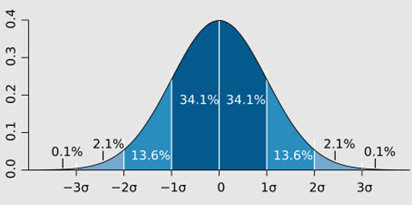

Figura 4: Escalas de desvio-padrão de uma distribuição normal.

Uma consequência da distribuição normal é que ela pode ser compartimentada em escalas de desvio-padrão, de forma que um desvio-padrão para mais ou para menos no entorno da média recubra aproximadamente 68,2% de toda a distribuição. Aumentando a quantidade de desvios-padrão, aumenta-se tal cobertura.

Assim, uma medida oportuna de ser verificada em inventários é quantos erros-padrão resultariam em um recobrimento de 95%? Essa pergunta define dois conceitos importantíssimos da amostragem e de inventários florestais: erro de amostragem e intervalo de confiança.

O erro de amostragem $E$ é calculado como

$$E = t_{n-1;1-\alpha/2}\cdot s_{\bar{y}}$$

Onde $t_{n-1;1-\alpha/2}$ é o valor da distribuição *t*-Student com $n-1$ graus de liberdade que representa o quantil de significância $\alpha$, e $s_{\bar{y}}$ é o erro padrão.

O valor $\alpha$ é chamado de nível de significância (ou erro Tipo I), e representa o complemento do nível de confiança, de forma que um nível de confiança 0,95 (95%) representará um nível de significância de 0,05, pois $0{,}95 = 1-\alpha$, logo $\alpha = 1-0{,}95$.

Note que, se $t=1$, então o erro de amostragem será aproximadamente equivalente a 68,2% da distribuição. Se $t=2$, será equivalente a aproximadamente 95,4%. A conferência com tabelas de probabilidade da distribuição *t*-Student permite encontrar o valor exato de $t$ para que recubra exatamente 95%. Tal valor sempre depende do tamanho da amostra $n$, pois a distribuição tem como parâmetro os graus de liberdade. Se $n$ for suficientemente grande, haverá convergência para a distribuição normal. Nesse caso, o valor para se chegar a 95% seria aproximadamente 1,96. Apesar de não obrigatório, é comum utilizar $\alpha = 0{,}05$, e a literatura técnica quase sempre utiliza tal valor como referência.

O erro de amostragem $E$ também pode ser escrito em sua forma relativa $E\%$, calculado como a proporção do erro no entorno da média amostral:

$$E\% = \frac{E}{\bar{y}}\cdot 100$$

Onde $E\%$ representa o erro relativo.

Esse erro relativo $E\%$ é o principal critério de avaliação de inventários florestais e normalmente não deve ultrapassar 10%. Essa é a precisão exigida por muitos órgãos ambientais para aceitar projetos que envolvam inventários florestais, tais quais inventários para supressão de áreas e projetos de manejo florestal sustentável (PMFS).

## 4.8 Intervalos de confiança

Calculado o erro de amostragem, a próxima etapa é calcular o intervalo de confiança. Como já se sabe o valor de $E$ cujo desvio no entorno da média recobre 95% da distribuição, então agora basta encontrar os valores correspondentes na distribuição da seguinte forma:

$$IC = P\left(\bar{y} - t_{n-1;1-\alpha/2}\,s_{\bar{y}} \leq \bar{Y} \leq \bar{y} + t_{n-1;1-\alpha/2}\,s_{\bar{y}}\right) = 0{,}95$$

Onde $IC$ representa o intervalo de confiança.

É percebível que o intervalo de confiança nada mais é que a soma ou subtração do erro de amostragem no entorno da média amostral. Para tornar a equação mais genérica, é possível trocar 0,95 por $1-\alpha$. O raciocínio dessa abordagem é o de que não se sabe a verdadeira média paramétrica $\bar{Y}$; porém, se for estipulado um intervalo que recobre, digamos, 95% de toda a distribuição, então existe uma probabilidade de 95% de que o valor paramétrico estará contido no intervalo.

## 4.9 Suficiência e intensidade amostral

Outro resultado da teoria da amostragem, e de caráter fundamental em inventários florestais, é o cálculo da intensidade amostral. Seja o erro amostral $E$ elevado ao quadrado:

$$E^2 = (t\cdot s_{\bar{y}})^2$$

Aqui, $t$ é o quantil da distribuição *t*-Student; será omitido o índice $n-1;1-\alpha/2$.

$$E^2 = (t\cdot s_{\bar{y}})^2 = t^2 s_{\bar{y}}^2 = t^2\hat{V}[\bar{y}] = t^2\cdot\frac{s^2}{n}\left(\frac{N-n}{N}\right)$$

Perceba que o erro amostral $E$ é função do tamanho amostral $n$ e da variância da amostra $s^2$. Se resolvermos para $n$,

$$\begin{aligned}
E^2 &= t^2\cdot\frac{s^2}{n}\left(\frac{N-n}{N}\right) \\
nNE^2 &= t^2 s^2 N - t^2 s^2 n \\
nNE^2 + t^2 s^2 n &= t^2 s^2 N \\
n(NE^2 + t^2 s^2) &= t^2 s^2 N \\
n &= \frac{t^2 s^2 N}{NE^2 + t^2 s^2} = {t^2s^2N \over N\left(E^2 + {t^2s^2 \over N} \right)} = \frac{t^2 s^2}{E^2 + \frac{t^2 s^2}{N}}
\end{aligned}
\tag{7}$$

Teremos o tamanho da amostra resultante da variabilidade $s^2$ e do erro $E$ estabelecido. Portanto, é possível encontrar o tamanho de amostra necessário para que se obtenha um erro $E$ predefinido, desde que se tenha uma estimativa prévia de $s^2$ antes do inventário.

O valor de $s^2$ pode ser obtido preferencialmente por um inventário piloto, em que algumas parcelas de inventário são realizadas a campo e o inventário é processado. Caso nesse inventário piloto o erro de amostragem $E$ tenha sido superior ao estipulado, então pode-se fazer uso do Resultado 7.

Note ainda que o Resultado 7 faz uso do erro de amostragem em termos absolutos, na escala da variável resposta, porém é possível utilizar a notação do erro relativo $E\%$ para delimitação de um erro relativo máximo:

$$E = \frac{E\%\,\bar{y}}{100}$$

$$E^2 = \left(\frac{E\%\,\bar{y}}{100}\right)^2 = \frac{E\%^2\bar{y}^2}{100^2} = t^2\cdot\frac{s^2}{n}\left(\frac{N-n}{N}\right)$$

$$E\%^2 = \frac{t^2 s^2\cdot 100^2}{n\bar{y}^2}\left(\frac{N-n}{N}\right)$$

Veja que

$$\frac{s^2\cdot 100^2}{\bar{y}^2} = \left(\frac{s}{\bar{y}}\cdot 100\right)^2 = (CV\%^2)$$

isto é, o coeficiente de variação de $y_i$ em porcentagem. Portanto,

$$\begin{aligned}
E\%^2 &= \frac{t^2 CV\%^2}{n}\left(\frac{N-n}{N}\right) \\
nNE\%^2 &= t^2 CV\%^2 N - t^2 CV\%^2 n \\
n(NE\%^2 + t^2 CV\%^2) &= t^2 CV\%^2 N \\
n &= \frac{t^2 CV\%^2 N}{NE\%^2 + t^2 CV\%^2} = \frac{t^2 CV\%^2}{E\%^2 + \frac{t^2 CV\%^2}{N}}
\end{aligned}
\tag{8}$$

Quando a população é considerada infinita, os cálculos ficam muito mais simplificados:

$$n = \frac{t^2 s^2}{E^2} = \frac{t^2 CV\%^2}{E\%^2}$$

Ainda outra maneira de determinar a intensidade amostral é utilizar um critério de custos. Para isso, autores como Péllico Netto e Brena (1997) apresentam uma função de custo em função do número de parcelas de inventário no desenho de ACS:

$$C = C_0 + C_1\cdot n
\qquad
n = \frac{C-C_0}{C_1}$$

Onde $C$ é o custo total admitido, $C_0$ são os custos fixos e $C_1$ são os custos variáveis, que dependem do número de parcelas realizadas.

A formulação da função de custo difere da apresentada por Péllico Netto e Brena (1997), pois os autores separam a função de custo entre os componentes de linha e coluna do *grid* de sistematização da amostra. Mas é intuitivo pensar que, se o número de parcelas é função do custo máximo permitido, então o número de parcelas em si é o principal custo variável.

# 5 Utilização de amostragem sistemática

Diante do exposto, é evidente a dificuldade, do ponto de vista estatístico, em analisar uma amostra sistemática. Mas, também como já apresentado, maior ainda é o esforço em possibilitar a análise desse tipo de desenho amostral. A extensa dedicação e o esforço teórico para o desenvolvimento da amostragem sistemática são facilmente justificados pela facilidade de planejamento e organização prática desse desenho.

Na área florestal não seria diferente. A amostragem sistemática é o processo de amostragem mais utilizado na iniciativa privada. Além disso, é o plano amostral utilizado para delimitação das unidades de conglomerado do Inventário Florestal Nacional.

# 6 Novas tecnologias

A Amostragem Aleatória Simples (ACS) continua sendo uma das bases metodológicas mais utilizadas nos inventários florestais. No entanto, nos últimos anos, avanços tecnológicos têm proporcionado melhorias substanciais na sua aplicação, tanto na coleta quanto no processamento dos dados.

Na coleta de dados, o uso de *softwares* móveis como o Mata Nativa permite realizar medições e cálculos em campo com mais agilidade e segurança. Esses aplicativos integram GPS, banco de dados e ferramentas estatísticas, favorecendo o rigor na seleção aleatória das unidades amostrais e facilitando o controle da amostragem durante a execução do inventário.

Além disso, dispositivos com sensores avançados, como drones equipados com LiDAR, têm sido incorporados aos inventários para mapear previamente a área de estudo. Isso possibilita uma estratificação mais refinada, identificação de áreas de acesso difícil e, em alguns casos, até a substituição parcial da coleta de campo, otimizando tempo e recursos.

No processamento dos dados, ferramentas como o Katam™ Forest automatizam a análise e a estimativa de variáveis dendrométricas, como altura e diâmetro, a partir de imagens capturadas em campo ou por sensores remotos. Junto disso, modelos de regressão mais sofisticados e o uso de aprendizado de máquina têm permitido reduzir o erro amostral e aumentar a precisão dos estimadores derivados da ACS.

Essas inovações, embora não alterem o fundamento estatístico da ACS — que permanece baseado na seleção equiprovável das unidades —, ampliam sua aplicabilidade e eficiência operacional, tornando-a mais robusta frente às exigências técnicas e logísticas dos inventários florestais modernos.

# 7 Conclusão

A amostragem sistemática, embora apresente limitações teóricas em comparação com os métodos aleatórios clássicos, consolidou-se como uma das estratégias mais eficazes e operacionais para inventários florestais. Sua principal força está na praticidade de campo, garantindo cobertura uniforme da área e facilitando o deslocamento e a localização das unidades amostrais. Sob determinadas condições, pode até oferecer maior precisão do que a amostragem aleatória simples, especialmente quando a variabilidade na população é bem representada pela estrutura sistemática da amostra.

No entanto, essa simplicidade operacional vem acompanhada de desafios estatísticos. A dependência entre unidades e a dificuldade em estimar a variância de forma não tendenciosa exigem que a sistemática seja cuidadosamente interpretada. O reconhecimento de sua equivalência aproximada com técnicas como amostragem por conglomerados ou estratificada permite utilizar abordagens alternativas para inferência estatística, como a separação em subgrupos ou a adoção de múltiplos inícios aleatórios.

A prática corrente de tratar amostras sistemáticas como se fossem aleatórias simples pode ser aceitável em determinadas circunstâncias, mas deve ser sempre acompanhada de uma avaliação da distribuição espacial da variável de interesse. A literatura sugere que, na ausência de padrões periódicos ou autocorrelações estruturais, a sistemática pode fornecer estimativas consistentes e eficientes, embora careça de estimadores exatos para a variância.

Por fim, o avanço de tecnologias como sensores remotos, *softwares* de mapeamento e análise, e métodos computacionais de inferência, amplia o potencial da amostragem sistemática e mitiga algumas de suas limitações clássicas. Em um contexto florestal, sua adoção deve considerar não apenas a viabilidade estatística, mas também a logística e os objetivos do inventário, reconhecendo que o sucesso de um plano amostral está na harmonia entre a teoria estatística, a realidade do campo e os recursos disponíveis.

# 8 Referências

COCHRAN, W. G. **Sampling techniques**. John Wiley & Sons, 1977.

PÉLLICO NETTO, S.; BRENA, D. A. **Inventário florestal**. Curitiba, 1997. 316 p.

QUEIROZ, W. T. **Amostragem em Inventário Florestal**. Belém, PA: EDUFRA, 2012. 441 p.